# Analyzing Popular News Stories

### The results will shock you!

#### By: Alex Jerome and Sanjana Chowdhury

## Idea

In this day and age with news sharing so prevalent, it’s interesting to see what in news attracts so much attention from people. What makes an article more shareable than others? Is there a trend as to which articles are shared more? The contents of an article may influence how the reader perceives the article and the different aspects and data that are recorded from news articles, and what we can so with them.

## Data

### Data Scraping

We used data from webhose.io. What made this data source so useful, despite the difficult setup, was that they had already done some NLP (Natural Language Processing).

For each post, they had already extracted the following data. It looked a bit like this

- News article UniqueID ("uuid")
- News article subjects
  - Persons
    - name
    - sentiments
  - Organizations
    - name
    - sentiments
  - Locations
    - name
    - sentiments
- News article social media shares per platform
  - facebook
    - likes
    - shares
  - comments
  - twitter
  - pinterest
- News article popularity metric (scale 1-10, [read more here](https://webhose.io/blog/api/webhose-io-tip-search-for-top-performing-viral-posts/))
- News article spamminess metric (scale 0-1)

#### “Popular News Articles”

Using this API key, we can retrieve several hundred data points at a time. From these data points, you can make them into a dictionary, turn that dictionary into a pandas dataframe, and turn that dataframe into a csv file. This seems really simple, but when processing over 80,000 JSON files, it takes an incredible amount of time and processing power, and we ourselves ran into quite a few issues while doing this (over 12 hours worth of trouble).

### Data Processing

Because these JSON files were essentially python dictionaries with a few levels in depth (as per the example tree above), we couldn't directly import them into Python. Rather, we had to import the dictionary, and then clean the data up to make sure it could be put into a Pandas DataFrame.

The way this was done is that for each "news article subject" or "tag", we created a new row in the dataframe that related it's name and sentiment to the unique ID as to comply with [Tidy Data Standards](https://www.jstatsoft.org/index.php/jss/article/view/v059i10/v59i10.pdf).

Lucky for you, we turned all of this into a few csv files, all categorized differently depending on what data you want to look at. You can easily copy the files and put them in the same folder as your notebook from the following github link:

https://github.com/AlexEJerome/CMSC320-Tutorial.git

There is no df_all.csv in this above. The reason being, that this file is over 100MB and github will not store that. Therefore, to create df_all.csv on your machine, simply append df_organizations, df_persons, and df_locations together.

To do this, either follow the code below, or, better yet, try it yourself and follow these links to find out how to read in csv's into Pandas, convert them into dataframes, append them, and save them as csv's.

- https://pandas.pydata.org/pandas-docs/stable/generated/pandas.read_csv.html
- https://pandas.pydata.org/pandas-docs/stable/generated/pandas.DataFrame.append.html
- https://pandas.pydata.org/pandas-docs/stable/generated/pandas.DataFrame.to_csv.html

We moved the code to gather the said data to the appendix, so you do not have to scroll through it to read about the data analysis.

#### Imported Data

So below is the imported data from the CSVs mentioned above. We displayed a subset of the 627948 rows contained in df_all.

```python
import pandas as pd
df_persons = pd.read_csv("df_persons"+".csv").drop(['Unnamed: 0'], axis=1)
df_organizations = pd.read_csv("df_organizations"+".csv").drop(['Unnamed: 0'], axis=1)
df_locations = pd.read_csv("df_locations"+".csv").drop(['Unnamed: 0'], axis=1)
df_all = pd.read_csv("df_all"+".csv").drop(['Unnamed: 0'], axis=1)
df_notags = pd.read_csv("df_notags"+".csv").drop(['Unnamed: 0'], axis=1)


# display(df_all)
```

|  | domain_rank | fb_comments | fb_likes | fb_shares | performance_score | sentiment | site | spam_score | tag | title | uuid |
| --- | --- | --- | --- | --- | --- | --- | --- | --- | --- | --- | --- |
| 0 | 3307.0 | 51145 | 297156 | 19368 | 10 | negative | newsweek.com | 0.672 | alexandria ocasio-cortez | Alexandria Ocasio-Cortez Wants to Replace Colu... | 6110cf3b1a50615ebacd4189abd4c2b143c28278 |
| 1 | 3307.0 | 51145 | 297156 | 19368 | 10 | none | newsweek.com | 0.672 | david martosko | Alexandria Ocasio-Cortez Wants to Replace Colu... | 6110cf3b1a50615ebacd4189abd4c2b143c28278 |
| 2 | 3307.0 | 51145 | 297156 | 19368 | 10 | none | newsweek.com | 0.672 | martosko | Alexandria Ocasio-Cortez Wants to Replace Colu... | 6110cf3b1a50615ebacd4189abd4c2b143c28278 |
| 3 | 3307.0 | 51145 | 297156 | 19368 | 10 | none | newsweek.com | 0.672 | ocasio-cortez | Alexandria Ocasio-Cortez Wants to Replace Colu... | 6110cf3b1a50615ebacd4189abd4c2b143c28278 |
| 4 | 3307.0 | 51145 | 297156 | 19368 | 10 | none | newsweek.com | 0.672 | christopher columbus | Alexandria Ocasio-Cortez Wants to Replace Colu... | 6110cf3b1a50615ebacd4189abd4c2b143c28278 |
| 5 | 139.0 | 147614 | 249425 | 36600 | 10 | negative | huffingtonpost.com | 0.000 | trump | Every President Recited This Prayer Except Tru... | d13abf959e176105e8be4a8715f4e74434eb2cfc |
| 6 | 139.0 | 147614 | 249425 | 36600 | 10 | none | huffingtonpost.com | 0.000 | michael b. jordan | Every President Recited This Prayer Except Tru... | d13abf959e176105e8be4a8715f4e74434eb2cfc |
| 7 | 139.0 | 147614 | 249425 | 36600 | 10 | none | huffingtonpost.com | 0.000 | donald trump | Every President Recited This Prayer Except Tru... | d13abf959e176105e8be4a8715f4e74434eb2cfc |
| 8 | 139.0 | 147614 | 249425 | 36600 | 10 | none | huffingtonpost.com | 0.000 | george h. w. bush | Every President Recited This Prayer Except Tru... | d13abf959e176105e8be4a8715f4e74434eb2cfc |
| 9 | 139.0 | 147614 | 249425 | 36600 | 10 | none | huffingtonpost.com | 0.000 | stallone | Every President Recited This Prayer Except Tru... | d13abf959e176105e8be4a8715f4e74434eb2cfc |
| 10 | 139.0 | 147614 | 249425 | 36600 | 10 | none | huffingtonpost.com | 0.000 | george h.w. bush | Every President Recited This Prayer Except Tru... | d13abf959e176105e8be4a8715f4e74434eb2cfc |
| 11 | 139.0 | 147614 | 249425 | 36600 | 10 | none | huffingtonpost.com | 0.000 | melania trump | Every President Recited This Prayer Except Tru... | d13abf959e176105e8be4a8715f4e74434eb2cfc |
| 12 | 139.0 | 147614 | 249425 | 36600 | 10 | none | huffingtonpost.com | 0.000 | richard marx | Every President Recited This Prayer Except Tru... | d13abf959e176105e8be4a8715f4e74434eb2cfc |
| 13 | 584.0 | 14186 | 248173 | 24123 | 10 | negative | cbsnews.com | 0.544 | jim mcgrath | George H.W. Bush's service dog Sully lays by h... | 05b55724a62642ec481b527c7815cd8b6879e697 |
| 14 | 584.0 | 14186 | 248173 | 24123 | 10 | negative | cbsnews.com | 0.544 | george h.w. bush | George H.W. Bush's service dog Sully lays by h... | 05b55724a62642ec481b527c7815cd8b6879e697 |
| 15 | 584.0 | 14186 | 248173 | 24123 | 10 | none | cbsnews.com | 0.544 | bush | George H.W. Bush's service dog Sully lays by h... | 05b55724a62642ec481b527c7815cd8b6879e697 |
| 16 | 1186.0 | 17586 | 198573 | 9756 | 10 | neutral | today.com | 0.996 | george w. bush | George W. Bush and Michelle Obama continue tra... | 3c2649c1e2893d3f903e30063fe70a51f8da96e2 |
| 17 | 1186.0 | 17586 | 198573 | 9756 | 10 | neutral | today.com | 0.996 | michelle obama | George W. Bush and Michelle Obama continue tra... | 3c2649c1e2893d3f903e30063fe70a51f8da96e2 |
| 18 | 1186.0 | 17586 | 198573 | 9756 | 10 | none | today.com | 0.996 | drew weisholtz | George W. Bush and Michelle Obama continue tra... | 3c2649c1e2893d3f903e30063fe70a51f8da96e2 |
| 19 | 1186.0 | 17586 | 198573 | 9756 | 10 | none | today.com | 0.996 | obama | George W. Bush and Michelle Obama continue tra... | 3c2649c1e2893d3f903e30063fe70a51f8da96e2 |
| 20 | 1186.0 | 17586 | 198573 | 9756 | 10 | none | today.com | 0.996 | bush | George W. Bush and Michelle Obama continue tra... | 3c2649c1e2893d3f903e30063fe70a51f8da96e2 |
| 21 | 1186.0 | 17586 | 198573 | 9756 | 10 | none | today.com | 0.996 | george h.w. bush | George W. Bush and Michelle Obama continue tra... | 3c2649c1e2893d3f903e30063fe70a51f8da96e2 |
| 22 | 1186.0 | 17586 | 198573 | 9756 | 10 | none | today.com | 0.996 | john mccain | George W. Bush and Michelle Obama continue tra... | 3c2649c1e2893d3f903e30063fe70a51f8da96e2 |
| 23 | 1186.0 | 17586 | 198573 | 9756 | 10 | none | today.com | 0.996 | trump | George W. Bush and Michelle Obama continue tra... | 3c2649c1e2893d3f903e30063fe70a51f8da96e2 |
| 24 | 584.0 | 15005 | 197931 | 20243 | 10 | none | cbsnews.com | 0.000 | dane neller | Small bookstores are booming after nearly bein... | f423053a061255382ad1cd5ba37da92b93d805b7 |
| 25 | 81.0 | 94401 | 197419 | 19380 | 10 | negative | cnn.com | 0.000 | trump | Trump: I'm thankful for the difference I've ma... | 6bf05f1935bf304834b694db85704e09b448c537 |
| 26 | 81.0 | 94401 | 197419 | 19380 | 10 | negative | cnn.com | 0.000 | donald trump | Trump: I'm thankful for the difference I've ma... | 6bf05f1935bf304834b694db85704e09b448c537 |
| 27 | 81.0 | 94073 | 197419 | 19380 | 10 | negative | cnn.com | 0.000 | trump | Trump: I'm thankful for the difference I've ma... | 6258e202b52da859edf569623b7a99b3ad0e7fc3 |
| 28 | 81.0 | 94073 | 197419 | 19380 | 10 | negative | cnn.com | 0.000 | donald trump | Trump: I'm thankful for the difference I've ma... | 6258e202b52da859edf569623b7a99b3ad0e7fc3 |
| 29 | 185.0 | 7584 | 185608 | 27197 | 10 | none | foxnews.com | 0.000 | merrick | California church’s untouched wooden cross bec... | b38db96a257415070c2642f67c50fa89d23f48a8 |
| ... | ... | ... | ... | ... | ... | ... | ... | ... | ... | ... | ... |
| 627918 | 387.0 | 182 | 501 | 192 | 1 | negative | wsj.com | 0.564 | china | Trump, After Boosting U.S. Military Budget, Sa... | c774ec4595907701ea68ace0a9c43f1dd86ddc43 |
| 627919 | 387.0 | 182 | 501 | 192 | 1 | negative | wsj.com | 0.564 | russia | Trump, After Boosting U.S. Military Budget, Sa... | c774ec4595907701ea68ace0a9c43f1dd86ddc43 |
| 627920 | 1337.0 | 1 | 501 | 4 | 0 | none | hindustantimes.com | 0.000 | australia | India vs Australia: Didn’t know where to draw ... | 0dea0721fa8f856ea7458eb538d59a890b1028eb |
| 627921 | 1337.0 | 1 | 501 | 4 | 0 | none | hindustantimes.com | 0.000 | india | India vs Australia: Didn’t know where to draw ... | 0dea0721fa8f856ea7458eb538d59a890b1028eb |
| 627922 | 1337.0 | 1 | 501 | 4 | 0 | none | hindustantimes.com | 0.000 | adelaide oval | India vs Australia: Didn’t know where to draw ... | 0dea0721fa8f856ea7458eb538d59a890b1028eb |
| 627923 | 1337.0 | 1 | 501 | 4 | 0 | none | hindustantimes.com | 0.000 | adelaide | India vs Australia: Didn’t know where to draw ... | 0dea0721fa8f856ea7458eb538d59a890b1028eb |
| 627924 | 1337.0 | 1 | 501 | 4 | 0 | none | hindustantimes.com | 0.000 | ravichandran ashwin | India vs Australia: Didn’t know where to draw ... | 0dea0721fa8f856ea7458eb538d59a890b1028eb |
| 627925 | 5.0 | 102 | 501 | 40 | 0 | none | yahoo.com | 0.175 | papua new guinea | Duterte to fire another gov't exec upon return... | 13e4476ee97d1d805f12596e9f5308809a16e447 |
| 627926 | 5.0 | 102 | 501 | 40 | 0 | none | yahoo.com | 0.175 | philippines | Duterte to fire another gov't exec upon return... | 13e4476ee97d1d805f12596e9f5308809a16e447 |
| 627927 | 5.0 | 102 | 501 | 40 | 0 | none | yahoo.com | 0.175 | port moresby | Duterte to fire another gov't exec upon return... | 13e4476ee97d1d805f12596e9f5308809a16e447 |
| 627928 | 2435.0 | 260 | 501 | 181 | 1 | none | zerohedge.com | 0.000 | usa | Russia To Verify Whether USA Actually Landed O... | 5264e64c8ce3112ba41335c3d0a38074d25282f8 |
| 627929 | 2435.0 | 260 | 501 | 181 | 1 | none | zerohedge.com | 0.000 | russia | Russia To Verify Whether USA Actually Landed O... | 5264e64c8ce3112ba41335c3d0a38074d25282f8 |
| 627930 | 2435.0 | 260 | 501 | 181 | 1 | none | zerohedge.com | 0.000 | moon | Russia To Verify Whether USA Actually Landed O... | 5264e64c8ce3112ba41335c3d0a38074d25282f8 |
| 627931 | 2435.0 | 260 | 501 | 181 | 1 | none | zerohedge.com | 0.000 | moldova | Russia To Verify Whether USA Actually Landed O... | 5264e64c8ce3112ba41335c3d0a38074d25282f8 |
| 627932 | 9534.0 | 90 | 501 | 52 | 0 | none | consequenceofsound.net | 0.000 | the house that jack built reddit | Film Review: Lars von Trier Delivers His Divin... | 12adf3899026164d0a966fff9ec6ba2ce1c5c6b1 |
| 627933 | 9534.0 | 90 | 501 | 52 | 0 | none | consequenceofsound.net | 0.000 | cannes | Film Review: Lars von Trier Delivers His Divin... | 12adf3899026164d0a966fff9ec6ba2ce1c5c6b1 |
| 627934 | 9534.0 | 90 | 501 | 52 | 0 | none | consequenceofsound.net | 0.000 | washington | Film Review: Lars von Trier Delivers His Divin... | 12adf3899026164d0a966fff9ec6ba2ce1c5c6b1 |
| 627935 | 116.0 | 1 | 501 | 3 | 0 | none | indiatimes.com | 0.000 | ferozeshah kotla | Ranji Trophy: Ricky Bhui's special knock keeps... | cb056e3b7c25eb75c31caf89fdfa4a9749991c43 |
| 627936 | 116.0 | 1 | 501 | 3 | 0 | none | indiatimes.com | 0.000 | delhi | Ranji Trophy: Ricky Bhui's special knock keeps... | cb056e3b7c25eb75c31caf89fdfa4a9749991c43 |
| 627937 | 116.0 | 1 | 501 | 3 | 0 | none | indiatimes.com | 0.000 | andhra pradesh | Ranji Trophy: Ricky Bhui's special knock keeps... | cb056e3b7c25eb75c31caf89fdfa4a9749991c43 |
| 627938 | 631.0 | 69 | 501 | 52 | 0 | none | people.com | 0.000 | columbus | Kim Porter's Cause of Death Remains a Mystery ... | 1f00a2688bc8ed14d16de7a7b0d2c16d9f365636 |
| 627939 | 631.0 | 69 | 501 | 52 | 0 | none | people.com | 0.000 | georgia | Kim Porter's Cause of Death Remains a Mystery ... | 1f00a2688bc8ed14d16de7a7b0d2c16d9f365636 |
| 627940 | 631.0 | 69 | 501 | 52 | 0 | none | people.com | 0.000 | california | Kim Porter's Cause of Death Remains a Mystery ... | 1f00a2688bc8ed14d16de7a7b0d2c16d9f365636 |
| 627941 | 631.0 | 69 | 501 | 52 | 0 | none | people.com | 0.000 | toluca lake | Kim Porter's Cause of Death Remains a Mystery ... | 1f00a2688bc8ed14d16de7a7b0d2c16d9f365636 |
| 627942 | 3726.0 | 52 | 501 | 133 | 1 | none | dallasnews.com | 0.000 | dallas | Dallas may have laid out its best plan yet to ... | 3e0b7e137cda2f99f2ff5726e8caa39cb6cc2a1c |
| 627943 | 16719.0 | 120 | 501 | 158 | 1 | none | ynetnews.com | 0.000 | europe | CNN poll reveals depth of anti-Semitism in Europe | 381da940277eccff659bffc9261fa3efa5f2946a |
| 627944 | 842.0 | 73 | 501 | 71 | 0 | none | thedailybeast.com | 0.580 | white house | John Kelly Questioned by Mueller Investigators... | d18daa1ce45de251bf154724159d230cf918a253 |
| 627945 | 842.0 | 73 | 501 | 71 | 0 | none | thedailybeast.com | 0.580 | russia | John Kelly Questioned by Mueller Investigators... | d18daa1ce45de251bf154724159d230cf918a253 |
| 627946 | 804.0 | 352 | 501 | 94 | 0 | none | mirror.co.uk | 0.003 | bloxwich | Woman, 30, hunting for Christmas decorations f... | 6652146a064c39af7e1187130caaa1c50eff1e1a |
| 627947 | 804.0 | 352 | 501 | 94 | 0 | none | mirror.co.uk | 0.003 | uk | Woman, 30, hunting for Christmas decorations f... | 6652146a064c39af7e1187130caaa1c50eff1e1a |

627948 rows × 11 columns

## Exploratory Analysis:

### Do topics influence article performance?

From anecdotal evidence, both Sanjana and Alex confirmed that they look at certain news articles based on their topics. Was this true in general?

First, we wanted to see if certain tags in the data had different numbers of facebook likes on average. to do that, we imported seaborn, a data visualization tool, and created a simple box plot.

#### A Visual Inspection

The box plot from seaborn takes an "x" parameter, and a "y" parameter. In box plots, seaborn groups the y values from the data provided in the data parameter by the x parameter. Or in this case, Seaborn created a box plot fo facebook likes, grouped by tag, from the data provided in the 500 data point sample taken from df_all.

The results are below:

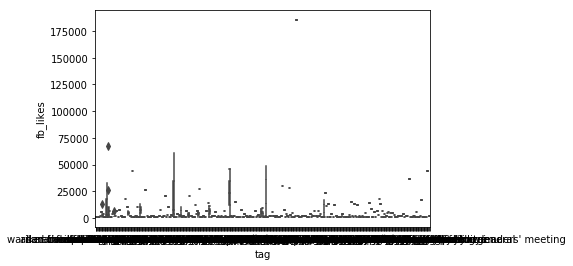

```python
# naive approach - each tag is independent
import seaborn as sns
sns.boxplot(x="tag", y="fb_likes", data = df_all.sample(n=500))
```

#### Boxplot results

This looks super messy, but just visually it looks that various tags have significantly varied performance. While the standarad deviations look a bit large, there could be a potential that a tag leads to some correlation in whether or not the post performs well!

#### Using Random Forests

This was the most difficult process, mainly because of some very rare bugs that did not really make too much sense. However, after about 10 hours of debugging, you can get it to work to!

##### Supervised Learning Processes (High Level)

First we had to determine what type of learning to do on the data set.

1. Supervised or Unsupervised Learning?
   - We had a set of data points (or tags) and results from those tags (popularity in facebook likes).
   - Because we had results that we were attempting to match the data up with, this is considered supervised learning
2. What strategy of supervised learning to use?

   [According to Wikipedia there are a few models](https://en.wikipedia.org/wiki/Supervised_learning):
   - [Support Vector Machines](https://en.wikipedia.org/wiki/Support_vector_machine)?
     - No, we aren't trying to discriminate between 2 types. We are trying to attach a number to a tag or group of tags
   - [Linear Regression](https://en.wikipedia.org/wiki/Linear_regression)?
     - No, tags don't have a numeric meaning attached to them. This means that a independent variable increase doesn't have meaning.
   - [Naive Bayes](https://en.wikipedia.org/wiki/Naive_Bayes_classifier)
     - No, similar to SVMs, the tags might not be completely independent.
   - [K-NN](https://en.wikipedia.org/wiki/K-nearest_neighbors_algorithm)
     - Maybe, but it could return nearest neighbors that are completely irrelevant. It was hard to decide on this one. There might be a better choice
   - [Decision Trees](https://en.wikipedia.org/wiki/Decision_tree_learning)
     - Ultimately the choice that was made because we could tie importance to specific tags, but not eliminate the dependence of other tags to tags higher up in the tree.
     - The "Random Forest" algorithm is considered the most stable of these versions. So we went with that.
3. How to use tags in decision trees?

   How do we use tags in decision trees then? Decision trees would have a similar issue to other algorithms - assigning random integers to tags with no inherit meaning.

   However, thinking back to our Class Lectures, specifically the class on NLP, a strategy that would work is to [create a frequency table to identify documents](https://www.cs.umd.edu/class/fall2018/cmsc320/lecs/cmsc320_f2018_lec16.pdf).

   To do this, we would need to do a cross tabulation of UUID with Tags from the df_all table.

   From there all we had to do was join the data from the frequency table, the uuid, and the metric (facebook likes), and put it into the Random Forest Algorithm.

   Easy, right?

##### Initial Process... not so easy.

So initially we tried to sample from all uuids from the "no tags" csv. This would ensure that no "uuid" was repeated since each unique id should be mentioned once. Then, once we got our sample from the "no tags" UUIDs, we would then iterate through each UUID, and where the UUID was in df_all, then we pull the corresponding tags.

Then, we would create a frequency table of the uuids versus tags. Then, we would use an inner join on the UUIDs from the frequency table and the UUIDs from the df_notags to ensure that only the UUIDs on the frequency table would have the metrics (like facebook likes) added to the columns.

However, when we would use sklearn's train_test_split function (which would effectively split the training data into training data and test data) we would run into an error:

`different number of data points / rows in provided data`.

Weird, right? We would take the same data, which would have the same length throughout, but when we got down to spliting it up into the frequency table and the resultant training data (the facebook likes), we would have different amounts of data, with what appeared to be the same amount of UUIDS. Strangely, the number of rows it differed by seemed to be dependent on the number of sampled rows. It would usually differ by about 0.2% of the number of sampled data points.

We did everything from resetting the index, grouping differently, sampling differently to try to figure out the issue.

##### A (Better) Solution

Perhaps a fundamental question was where was the error and why.

First looking at the data, we made the assumption that each post had a tag. That's not necessarily true. There were posts with unique IDs that didn't have tags. They therefore did not show up in the df_all.csv.

In addition, an inner join shouldn't be inconsistent by nature. But it clearly appeared to be. Because the error did not show up until the join, maybe the data wasn't the full problem?

To deal with this, we decided to completely eliminate the inner join. Instead, we would have to gather each table without joining.

Finally, when we got this to work, there was a low prediction score for tags to facebook likes. How could we fix this?

###### Summary of Potential issue areas:

- Inconsistent Data (Df_All['uuid'] $\neq$ df_notags['uuid']
- Inconsistent results of inner join
- Low prediction score (below 1%).

###### How we re-wrote the algorithm:

1. Instead of sampling from the DF_notags (where some uuids that aren't in df_all may be present), we sampled from DF_all after grouping it on uuid. We took the first 5000 tags in this case. Since the UUIDs are randomized, the actual first 5000 from a sorted list are also by nature randomized.
2. For every UUID from the sample above, we appended the relevant tags from df_all to the table.
3. Instead of trying to predict facebook likes, we instead tied it to the standardized metric provided by "Webhose.io" called "performance_score", which determined on a scale of 1-10 how well it performed. We grabbed the relevant scores from the sampled UUIDS above.
4. We re-wrote the Random Forest Algorithm to match the tutorial found [here](https://www.datacamp.com/community/tutorials/random-forests-classifier-python) to ensure that it worked correctly.

Scroll down to see the basic output of the code!

```python
# trying slightly different method because of strange sampling results
df_sample = df_all.copy()
df_sample = df_sample.groupby(['uuid']).count()
df_all_uuids = df_sample.index.to_series()
df_all_uuids_1000 = df_all_uuids.tolist()[:5000]
# display(df_all_uuids_1000_series)
```

```python
sample_df = pd.DataFrame(columns = list(df_all))
for uuid in df_all_uuids_1000:
    new_df = df_all[df_all['uuid'] == uuid]
    if not new_df.dropna().empty:
        sample_df = pd.concat([sample_df, new_df])
# display(sample_df)
```

|  | domain_rank | fb_comments | fb_likes | fb_shares | performance_score | sentiment | site | spam_score | tag | title | uuid |
| --- | --- | --- | --- | --- | --- | --- | --- | --- | --- | --- | --- |
| 59623 | 1455.0 | 3242 | 3917 | 302 | 3 | none | abc.net.au | 0.0 | valery | US agents shoot tear gas at migrants attemptin... | 000060d7623243db32e636522622b4278dce6276 |
| 59624 | 1455.0 | 3242 | 3917 | 302 | 3 | none | abc.net.au | 0.0 | ana zuniga | US agents shoot tear gas at migrants attemptin... | 000060d7623243db32e636522622b4278dce6276 |
| 319677 | 1455.0 | 3242 | 3917 | 302 | 3 | none | abc.net.au | 0.0 | ap | US agents shoot tear gas at migrants attemptin... | 000060d7623243db32e636522622b4278dce6276 |
| 319678 | 1455.0 | 3242 | 3917 | 302 | 3 | none | abc.net.au | 0.0 | milenio tv | US agents shoot tear gas at migrants attemptin... | 000060d7623243db32e636522622b4278dce6276 |
| 492762 | 1455.0 | 3242 | 3917 | 302 | 3 | none | abc.net.au | 0.0 | us | US agents shoot tear gas at migrants attemptin... | 000060d7623243db32e636522622b4278dce6276 |
| 492763 | 1455.0 | 3242 | 3917 | 302 | 3 | none | abc.net.au | 0.0 | tijuana | US agents shoot tear gas at migrants attemptin... | 000060d7623243db32e636522622b4278dce6276 |
| 492764 | 1455.0 | 3242 | 3917 | 302 | 3 | none | abc.net.au | 0.0 | mexico | US agents shoot tear gas at migrants attemptin... | 000060d7623243db32e636522622b4278dce6276 |
| 266958 | 13.0 | 416 | 555 | 365 | 3 | negative | msn.com | 0.0 | stormy daniels | Stormy Daniels: Michael Avenatti Filed Defamat... | 00006fd62d5b1481342efacda5444223b6e4e9bc |
| 266959 | 13.0 | 416 | 555 | 365 | 3 | negative | msn.com | 0.0 | daily bea | Stormy Daniels: Michael Avenatti Filed Defamat... | 00006fd62d5b1481342efacda5444223b6e4e9bc |
| 266960 | 13.0 | 416 | 555 | 365 | 3 | negative | msn.com | 0.0 | michael avenatti | Stormy Daniels: Michael Avenatti Filed Defamat... | 00006fd62d5b1481342efacda5444223b6e4e9bc |
| 266961 | 13.0 | 416 | 555 | 365 | 3 | none | msn.com | 0.0 | betsy woodruff | Stormy Daniels: Michael Avenatti Filed Defamat... | 00006fd62d5b1481342efacda5444223b6e4e9bc |
| 266962 | 13.0 | 416 | 555 | 365 | 3 | none | msn.com | 0.0 | donald trump | Stormy Daniels: Michael Avenatti Filed Defamat... | 00006fd62d5b1481342efacda5444223b6e4e9bc |
| 266963 | 13.0 | 416 | 555 | 365 | 3 | none | msn.com | 0.0 | avenatti | Stormy Daniels: Michael Avenatti Filed Defamat... | 00006fd62d5b1481342efacda5444223b6e4e9bc |
| 266964 | 13.0 | 416 | 555 | 365 | 3 | none | msn.com | 0.0 | michael | Stormy Daniels: Michael Avenatti Filed Defamat... | 00006fd62d5b1481342efacda5444223b6e4e9bc |
| 266965 | 13.0 | 416 | 555 | 365 | 3 | none | msn.com | 0.0 | kate briquelet | Stormy Daniels: Michael Avenatti Filed Defamat... | 00006fd62d5b1481342efacda5444223b6e4e9bc |
| 266966 | 13.0 | 416 | 555 | 365 | 3 | none | msn.com | 0.0 | daniels | Stormy Daniels: Michael Avenatti Filed Defamat... | 00006fd62d5b1481342efacda5444223b6e4e9bc |
| 446131 | 13.0 | 416 | 555 | 365 | 3 | negative | msn.com | 0.0 | trump against my wishes stormy daniels | Stormy Daniels: Michael Avenatti Filed Defamat... | 00006fd62d5b1481342efacda5444223b6e4e9bc |
| 446132 | 13.0 | 416 | 555 | 365 | 3 | none | msn.com | 0.0 | the daily beast | Stormy Daniels: Michael Avenatti Filed Defamat... | 00006fd62d5b1481342efacda5444223b6e4e9bc |
| 215559 | 2058.0 | 37 | 818 | 12 | 0 | neutral | hollywoodlife.com | 0.0 | justin bieber | Hailey Baldwin Excited To Spend Thanksgiving W... | 00007ebb0c78b6b6ed5660cee845bfdbe3b55934 |
| 215560 | 2058.0 | 37 | 818 | 12 | 0 | neutral | hollywoodlife.com | 0.0 | hailey baldwin | Hailey Baldwin Excited To Spend Thanksgiving W... | 00007ebb0c78b6b6ed5660cee845bfdbe3b55934 |
| 199303 | 313.0 | 91 | 922 | 246 | 2 | negative | usatoday.com | 0.0 | david pearson | David Pearson, NASCAR Hall of Famer and 3-time... | 0001a122fc2a03e9e2be51266d18267c5a4db767 |
| 199304 | 313.0 | 91 | 922 | 246 | 2 | none | usatoday.com | 0.0 | richard petty | David Pearson, NASCAR Hall of Famer and 3-time... | 0001a122fc2a03e9e2be51266d18267c5a4db767 |
| 199305 | 313.0 | 91 | 922 | 246 | 2 | none | usatoday.com | 0.0 | mike hembree | David Pearson, NASCAR Hall of Famer and 3-time... | 0001a122fc2a03e9e2be51266d18267c5a4db767 |
| 403773 | 313.0 | 91 | 922 | 246 | 2 | negative | usatoday.com | 0.0 | facebook email | David Pearson, NASCAR Hall of Famer and 3-time... | 0001a122fc2a03e9e2be51266d18267c5a4db767 |
| 403774 | 313.0 | 91 | 922 | 246 | 2 | negative | usatoday.com | 0.0 | nascar hall of famer | David Pearson, NASCAR Hall of Famer and 3-time... | 0001a122fc2a03e9e2be51266d18267c5a4db767 |
| 403775 | 313.0 | 91 | 922 | 246 | 2 | none | usatoday.com | 0.0 | nascar | David Pearson, NASCAR Hall of Famer and 3-time... | 0001a122fc2a03e9e2be51266d18267c5a4db767 |
| 403776 | 313.0 | 91 | 922 | 246 | 2 | none | usatoday.com | 0.0 | usatoday.com | David Pearson, NASCAR Hall of Famer and 3-time... | 0001a122fc2a03e9e2be51266d18267c5a4db767 |
| 403777 | 313.0 | 91 | 922 | 246 | 2 | none | usatoday.com | 0.0 | facebook | David Pearson, NASCAR Hall of Famer and 3-time... | 0001a122fc2a03e9e2be51266d18267c5a4db767 |
| 403778 | 313.0 | 91 | 922 | 246 | 2 | none | usatoday.com | 0.0 | nascar hall | David Pearson, NASCAR Hall of Famer and 3-time... | 0001a122fc2a03e9e2be51266d18267c5a4db767 |
| 575177 | 313.0 | 91 | 922 | 246 | 2 | none | usatoday.com | 0.0 | usa | David Pearson, NASCAR Hall of Famer and 3-time... | 0001a122fc2a03e9e2be51266d18267c5a4db767 |
| ... | ... | ... | ... | ... | ... | ... | ... | ... | ... | ... | ... |
| 420196 | 12951.0 | 2 | 723 | 6 | 0 | none | arynews.tv | 0.0 | senate | Headlines \| ARYNews \| 2200 \| 18 November 2018 | 114d5faaae5bf34ea3f1c1c7c0d87f1db1e56ed3 |
| 591515 | 12951.0 | 2 | 723 | 6 | 0 | none | arynews.tv | 0.0 | crown prince of abu dhabi | Headlines \| ARYNews \| 2200 \| 18 November 2018 | 114d5faaae5bf34ea3f1c1c7c0d87f1db1e56ed3 |
| 591516 | 12951.0 | 2 | 723 | 6 | 0 | none | arynews.tv | 0.0 | balochistan assembly | Headlines \| ARYNews \| 2200 \| 18 November 2018 | 114d5faaae5bf34ea3f1c1c7c0d87f1db1e56ed3 |
| 591517 | 12951.0 | 2 | 723 | 6 | 0 | none | arynews.tv | 0.0 | rawalpindi | Headlines \| ARYNews \| 2200 \| 18 November 2018 | 114d5faaae5bf34ea3f1c1c7c0d87f1db1e56ed3 |
| 591518 | 12951.0 | 2 | 723 | 6 | 0 | none | arynews.tv | 0.0 | balochistan | Headlines \| ARYNews \| 2200 \| 18 November 2018 | 114d5faaae5bf34ea3f1c1c7c0d87f1db1e56ed3 |
| 591519 | 12951.0 | 2 | 723 | 6 | 0 | none | arynews.tv | 0.0 | shopian | Headlines \| ARYNews \| 2200 \| 18 November 2018 | 114d5faaae5bf34ea3f1c1c7c0d87f1db1e56ed3 |
| 591520 | 12951.0 | 2 | 723 | 6 | 0 | none | arynews.tv | 0.0 | oman | Headlines \| ARYNews \| 2200 \| 18 November 2018 | 114d5faaae5bf34ea3f1c1c7c0d87f1db1e56ed3 |
| 183567 | 7403.0 | 23 | 1039 | 29 | 0 | none | khaleejtimes.com | 0.0 | daniel golebiowski | Plane breaks down, passengers asked to pay for... | 11509051266df7a2f6e8a93b5569cb579dec02cb |
| 183568 | 7403.0 | 23 | 1039 | 29 | 0 | none | khaleejtimes.com | 0.0 | adrian kubicki | Plane breaks down, passengers asked to pay for... | 11509051266df7a2f6e8a93b5569cb579dec02cb |
| 393595 | 7403.0 | 23 | 1039 | 29 | 0 | none | khaleejtimes.com | 0.0 | lot polish airlines | Plane breaks down, passengers asked to pay for... | 11509051266df7a2f6e8a93b5569cb579dec02cb |
| 565599 | 7403.0 | 23 | 1039 | 29 | 0 | none | khaleejtimes.com | 0.0 | beijing | Plane breaks down, passengers asked to pay for... | 11509051266df7a2f6e8a93b5569cb579dec02cb |
| 565600 | 7403.0 | 23 | 1039 | 29 | 0 | none | khaleejtimes.com | 0.0 | warsaw | Plane breaks down, passengers asked to pay for... | 11509051266df7a2f6e8a93b5569cb579dec02cb |
| 142491 | 1268.0 | 1200 | 1500 | 347 | 3 | negative | hollywoodreporter.com | 0.0 | donald trump | Trump Proposes State-Run Television... | 11513859dd13d238593ba0549f31170aa64cb50c |
| 142492 | 1268.0 | 1200 | 1500 | 347 | 3 | none | hollywoodreporter.com | 0.0 | jim acosta | Trump Proposes State-Run Television... | 11513859dd13d238593ba0549f31170aa64cb50c |
| 142493 | 1268.0 | 1200 | 1500 | 347 | 3 | none | hollywoodreporter.com | 0.0 | trump | Trump Proposes State-Run Television... | 11513859dd13d238593ba0549f31170aa64cb50c |
| 367890 | 1268.0 | 1200 | 1500 | 347 | 3 | negative | hollywoodreporter.com | 0.0 | worldwide network | Trump Proposes State-Run Television... | 11513859dd13d238593ba0549f31170aa64cb50c |
| 367891 | 1268.0 | 1200 | 1500 | 347 | 3 | negative | hollywoodreporter.com | 0.0 | trump proposes state-run television | Trump Proposes State-Run Television... | 11513859dd13d238593ba0549f31170aa64cb50c |
| 367892 | 1268.0 | 1200 | 1500 | 347 | 3 | none | hollywoodreporter.com | 0.0 | cnn | Trump Proposes State-Run Television... | 11513859dd13d238593ba0549f31170aa64cb50c |
| 367893 | 1268.0 | 1200 | 1500 | 347 | 3 | none | hollywoodreporter.com | 0.0 | voice of america and radio free europe/radio l... | Trump Proposes State-Run Television... | 11513859dd13d238593ba0549f31170aa64cb50c |
| 367894 | 1268.0 | 1200 | 1500 | 347 | 3 | none | hollywoodreporter.com | 0.0 | white house | Trump Proposes State-Run Television... | 11513859dd13d238593ba0549f31170aa64cb50c |
| 540656 | 1268.0 | 1200 | 1500 | 347 | 3 | none | hollywoodreporter.com | 0.0 | u.s. | Trump Proposes State-Run Television... | 11513859dd13d238593ba0549f31170aa64cb50c |
| 540657 | 1268.0 | 1200 | 1500 | 347 | 3 | none | hollywoodreporter.com | 0.0 | united states | Trump Proposes State-Run Television... | 11513859dd13d238593ba0549f31170aa64cb50c |
| 97505 | 313.0 | 1007 | 2253 | 350 | 3 | none | usatoday.com | 0.0 | vladimir putin | G-20 leaders summit: U.S. remains holdout on P... | 1152c824acb29b5be113bc8b5bed7fce900a049d |
| 97506 | 313.0 | 1007 | 2253 | 350 | 3 | none | usatoday.com | 0.0 | donald trump | G-20 leaders summit: U.S. remains holdout on P... | 1152c824acb29b5be113bc8b5bed7fce900a049d |
| 97507 | 313.0 | 1007 | 2253 | 350 | 3 | none | usatoday.com | 0.0 | putin | G-20 leaders summit: U.S. remains holdout on P... | 1152c824acb29b5be113bc8b5bed7fce900a049d |
| 97508 | 313.0 | 1007 | 2253 | 350 | 3 | none | usatoday.com | 0.0 | trump | G-20 leaders summit: U.S. remains holdout on P... | 1152c824acb29b5be113bc8b5bed7fce900a049d |
| 342597 | 313.0 | 1007 | 2253 | 350 | 3 | none | usatoday.com | 0.0 | world trade organization | G-20 leaders summit: U.S. remains holdout on P... | 1152c824acb29b5be113bc8b5bed7fce900a049d |
| 515985 | 313.0 | 1007 | 2253 | 350 | 3 | none | usatoday.com | 0.0 | u.s. | G-20 leaders summit: U.S. remains holdout on P... | 1152c824acb29b5be113bc8b5bed7fce900a049d |
| 515986 | 313.0 | 1007 | 2253 | 350 | 3 | none | usatoday.com | 0.0 | buenos aires | G-20 leaders summit: U.S. remains holdout on P... | 1152c824acb29b5be113bc8b5bed7fce900a049d |
| 515987 | 313.0 | 1007 | 2253 | 350 | 3 | none | usatoday.com | 0.0 | paris | G-20 leaders summit: U.S. remains holdout on P... | 1152c824acb29b5be113bc8b5bed7fce900a049d |

42593 rows × 11 columns

```python
sm_df = sample_df.copy().set_index('uuid')
sm_df = sm_df[~sm_df.index.duplicated()]['performance_score']
# display(sm_df)
```

```
uuid
000060d7623243db32e636522622b4278dce6276     3
00006fd62d5b1481342efacda5444223b6e4e9bc     3
00007ebb0c78b6b6ed5660cee845bfdbe3b55934     0
0001a122fc2a03e9e2be51266d18267c5a4db767     2
000213ca51e05cd2877fa273ab2b0628d5d1013e    10
0002aa9745a194f89685b4c016940e32dadef490     0
0003be1736cfd35ca63f8cc34765e60e8f6456a9     6
0004e6fb9efcaa5ff90a3a1dea03586c0708d11a     0
0005a62cbd56eb42c64082f6eadd71e2616d73b9     2
00079a4335c255e8be68f0e0caa8cb043ec27a46     1
000885b79a0cc33982b8a21bb7696ba9dc110103    10
000899e4aa23c503919e319129c516dbbd4b784a     1
00099d72a259f4e7e9a4225cd377807c96c48fd5    10
0009e750700e458ba3e77f6e6193b38ff92253dc     1
000a9f1fa20160a6730b76b010ff0e682b8df685     2
000b30ae0e9db014891ec6eeeecf1a344f768e7c     1
000d58e15af27b71deb9e3f2b02e0707e713deae    10
000d5cf4d0a6019d3f5b67df6d0ff47d34734cfa     8
000dbb31eed10a2759877a7936cea3755c1de9be     4
000def87cdc0a2f60ae793e9878274814e961fb9     3
000e32de50342d818947a5e392597148859a8912     4
000e7bb6bf43721d3bb67838f466d0d3c914a39a     2
000ef8956b3848f54807a132cfe9cba38c4a10cc     5
000fd1cb7adda6f4225d2d19eae2bda85a76000a     4
00114a81484f5110d0944726cd9e8ef0376af704     2
0012abae95d248d303182f275a1e4c11550735ae     0
0012b5dd7aa405ca2e5ab6462457d635802b79f3     0
0013f01f6daff1a56203dc502eb49a7c8656ea40     1
00147f746db683ba768735f44fad699f404f7633     0
00160c3a3f80905bc38bc936f62639cd9ca79e91    10
                                            ..
1138beb1581c746eae489f14f77430c536b69df2     0
1139ca4d76682fd93768310d5074cefccc155227    10
113b7197d12f5e1a941fa1862c4c5bdd9868ca78     0
113b8f127fe7832ccb41e5098904b302a7e21b31     1
113bc28d645632a2ccf943ffdb6f13a432725688     1
113c04be728fe3dfe138676f6c27b130720de58a     0
113c24c554133d944fdcaa4e7308d3ca6ab642fd     9
113ea04ebb99d1064337077e72582f3b53c84d35     4
```

[output cut: 8 more lines]

```
11463b0cff44883180e4d5a0f02f1fa70989a58f    10
1146985ddd945e722b2511d3eb669267dc4ee1e2     2
1146c642a5c4e79cffe1a550e54bd8007c1c114d     0
1148a06a60290b6c2c4e641aa897147b1469795d     1
1148aa6f9b061e6b7ae39b552a3c58aa56f6dae6     1
1149a1fa2f7b3aac7da53c67f5fe5c463f757977     1
114a80244b62828fc65670b4462a0c6d8b13b31b     0
114aade7f23b9dafeff2693d418b4c680b9fd52f     9
114b622d7b64b99120574b821d253c8db5bef11f    10
114cdd547a5c73238fedda5b7dfccafce86ea607     0
114d5faaae5bf34ea3f1c1c7c0d87f1db1e56ed3     0
11509051266df7a2f6e8a93b5569cb579dec02cb     0
11513859dd13d238593ba0549f31170aa64cb50c     3
1152c824acb29b5be113bc8b5bed7fce900a049d     3
Name: performance_score, Length: 4984, dtype: object
```

```python
# Clearly there's something to it, but there's also lots of variance here...
# and assuming tags interact we probably need to do a Random Forest
# To get there, it's a good idea to start with converting each tag to a frequency table per uuid

# NEW VERSION!

table = sample_df

freq_table = pd.crosstab(table['uuid'],table['tag'])

# Import train_test_split function
from sklearn.model_selection import train_test_split


X=freq_table  # Features
y=sm_df  # Labels
y=y.astype('int')

# Split dataset into training set and test set
# 70% training and 30% test
X_train, X_test, y_train, y_test = train_test_split(X, y, test_size=0.3)
```

```python
#Import Random Forest Model
from sklearn.ensemble import RandomForestClassifier

#Create a Gaussian Classifier
clf=RandomForestClassifier(n_estimators=10)

#Train the model using the training sets y_pred=clf.predict(X_test)
clf.fit(X_train,y_train)

y_pred=clf.predict(X_test)
```

```python
#Import scikit-learn metrics module for accuracy calculation
from sklearn import metrics
# Model Accuracy, how often is the classifier correct?
print("Accuracy:",metrics.accuracy_score(y_test, y_pred))
```

```
Accuracy: 0.31684491978609625
```

#### Random Forest Results:

Only 31% accuracy. While much better than the less than 1% accuracy, still not perfect. Out of curiousity, though, are there still some terms that had a higher impact?

Below is a list of top 10 important features generated by the code below:

```python
import matplotlib.pyplot as plt
import numpy as np
col = list(freq_table)
#modelname.feature_importance_
y_2 = clf.feature_importances_

top_10_feature_indexes = sorted(range(len(y_2)), key=lambda i: y_2[i], reverse=True)[:10]
for index in top_10_feature_indexes:
    print(col[index], y_2[index])
```

```
tanjug 0.008705433496935217
trump 0.005245956681892578
donald trump 0.002985857662829398
cnn 0.0029669740224087275
india 0.002863224013320546
uk 0.00282970589370247
u.s. 0.0024759728494087047
bbc news 0.0023241248402421913
brexit 0.002321952395120567
washington 0.0022970671926285454
```

#### Random Forest Analysis:

Interestingly enough, it appears that some terms definitely have an impact.

1. Divisiveness is important. We can see that both "Trump" and "Donald Trump" were spots 2 and 3 respectively on the list. In addition, Brexit comes in at 9th. Due to the divisiveness of both Brexit and Donald Trump it makes sense he would be a popular topic.
2. Your news organization matters. The first item on the feature importance list is "Tanjug" a Serbian-State owned news agency, along with CNN in 4th, and BBC News in 8th. It shows that the actual publisher of the news has an impact on the success of the article.
3. Location also mattered as India, UK, US, and Washington all had top placement.
4. It appears that actually that all categories of tags (locations, persons, and organizations) have some impact on the popularity of the article.

### Sentiment Popularity Analysis

One thing that is interesting is that each article has a bunch of tags, and all of those tags each have an associated sentiment to them. The possibilities are “positive”, “negative”, or “neutral”. Sentiment refers to how the tag is generally perceived. What we are going to explore is which overall sentiment of the article has the more likes or shares, and see if we can come up with any conclusions.

```python
#number of articles with tags which we will be analyzing
len(df_all.groupby('uuid').groups.keys())
```

```
73772
```

Overall sentiment is going to be our way to add a sentiment metric to the article and not just its tags. The sentiment metric is going to be called “sent_metric”, and this value will be associated with the tagged sentiment. The value will be initialized to 0, which is our neutral sentiment. If the sentiment is negative, the metric will be set to -1. Otherwise, if it’s positive, the metric will be set to 1. If there is no sentiment attached to the tag, then it won’t change.

The data is huge, like, over half of a million huge. That is because df_all has all the tags in all of the 70,000+ articles. When it comes to massive data sets and a standard laptop, it’s almost impossible to go through all of that data in a reasonable amount of time. Here, we chose a subset of the data and only processed 30,000 of the first tags that had a biased sentiment attached to them. Feel free to use other subsets of data, smaller or bigger subsets, randomize data from the dataframe, etc. Just beware, the bigger the data set you want to process, the more time and energy it will need. Processing 30,000 samples takes about a few minutes every time.

```python
#all the articles with biased tags will be calculated.
#df_all is such a large set of tags, we're only going to
#df_sent is just a sample from df_all with a new sentiment column that will be initialized

df_sent= df_all[df_all['sentiment']!="none"][df_all['sentiment']!="neutral"][:30000].copy()
```

```python
df_sent.head()
```

[output not shown]

The next part is a little tricky.

We see that in df_all, the dataframe with all our tags, there are multiple tags per uuid, which is unique to the article, but not unique in the dataframe. We can use ‘groupby’ to group all these tags by their article, and then sum the sent_metric of each tag to come up with an overall sentiment.

```python
#initialize a new column for our metrics
df_sent['sent_metric']= 0
#turn the sentiment metrics into numerical values in df_sent
for i, row in df_sent.iterrows():
    if row['sentiment']=="negative":
        df_sent.loc[i, 'sent_metric']= df_sent.loc[i, 'sent_metric'] - 1
    elif row['sentiment']=="positive":
        df_sent.loc[i, 'sent_metric']= df_sent.loc[i, 'sent_metric'] + 1
```

To store this new data and other things we’ll need later, create a new dataframe that will store information for each article. We’ll call this dataframe “df_art”, and create a column called “total_sent” to represent the overall sentiment of the article.

For each group, call .sum() on the group’s sent_metric to find the total of all the tags of that article. Store this sum in df_art to the corresponding index.

```python
#create a new dataframe to store our statistics per article
df_art= pd.DataFrame()
df_art['uuid']= ""
df_art['total_sent']= 0
#use groupby to group by article, and then calculate the sum of sent_metric to get the total sent_metric of the article
c= 0 #use c to index consistently per article
for name, group in df_sent.groupby('uuid'):
    df_art.loc[c, 'uuid']= name
    df_art.loc[c, 'total_sent']= group['sent_metric'].sum()
    c= c+1
```

```python
#peep our total sentiments
df_art.head()
```

|  | uuid | total_sent |
| --- | --- | --- |
| 0 | 000213ca51e05cd2877fa273ab2b0628d5d1013e | -1.0 |
| 1 | 000885b79a0cc33982b8a21bb7696ba9dc110103 | -2.0 |
| 2 | 000899e4aa23c503919e319129c516dbbd4b784a | -1.0 |
| 3 | 00099d72a259f4e7e9a4225cd377807c96c48fd5 | -3.0 |
| 4 | 000a9f1fa20160a6730b76b010ff0e682b8df685 | -1.0 |

There are various ways of looping through groups and indexing and setting values in a dataframe. The way we did it here is by using an index variable, c, to allow us to keep track of where we are in the data frame while going through each group.

Then, add more variables to the dataframe using the same methodology. These variables will make it a lot easier to graph the data points. Here, add the facebook likes and shares.

```python
#match fb likes from the article to the sentiments
df_art['fb_likes']= 0
df_art['fb_shares']= 0

#use a loop to go through each group like we did previously to keep the uuids consistent
c= 0 #use c to index consistently per article
for name, group in df_sent.groupby('uuid'):
    df_art.loc[c, 'fb_likes']= group.iloc[0]['fb_likes'] #each member in a group should have the same number of likes and shares
    df_art.loc[c, 'fb_shares']= group.iloc[0]['fb_shares']
    c= c+1
```

Also, create a column called “sign_of_sent” that says if the overall sentiment is either negative or positive. This will help visualize and separate the negative sentiments from the positive sentiments.

```python
#add a new column to df_art that says if our total_sent is positive or negative
#this will aid us in graphing and creating a better analysis
df_art['sign_of_sent']= ""


for i, row in df_art.iterrows():
    if row['total_sent'] > 0:
        df_art.loc[i, 'sign_of_sent']= "positive"
    elif row['total_sent'] < 0:
        df_art.loc[i, 'sign_of_sent']= "negative"
    else:
        df_art.loc[i, 'sign_of_sent']= "neutral"
```

```python
#look at everything we've matched!
df_art.head()
```

|  | uuid | total_sent | fb_likes | fb_shares | sign_of_sent |
| --- | --- | --- | --- | --- | --- |
| 0 | 000213ca51e05cd2877fa273ab2b0628d5d1013e | -1.0 | 1766 | 5780 | negative |
| 1 | 000885b79a0cc33982b8a21bb7696ba9dc110103 | -2.0 | 19259 | 5123 | negative |
| 2 | 000899e4aa23c503919e319129c516dbbd4b784a | -1.0 | 2597 | 126 | negative |
| 3 | 00099d72a259f4e7e9a4225cd377807c96c48fd5 | -3.0 | 9365 | 1748 | negative |
| 4 | 000a9f1fa20160a6730b76b010ff0e682b8df685 | -1.0 | 2874 | 261 | negative |

Look! We’re almost done!

Graph the plots using seaborn, which is really easy and intuitive. Pass in the dataframe, and which values you want your x and y to be. In this case, the x axis is the overall sentiment and the y access would be the number of facebook likes or shares.

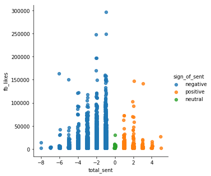

```python
#now, we can graph a scatterplot showing our details
import seaborn as sns

#total_sent vs fb_likes
sns.lmplot(x= 'total_sent', y= 'fb_likes', data=df_art, hue= 'sign_of_sent', x_jitter= .07, fit_reg=False)
```

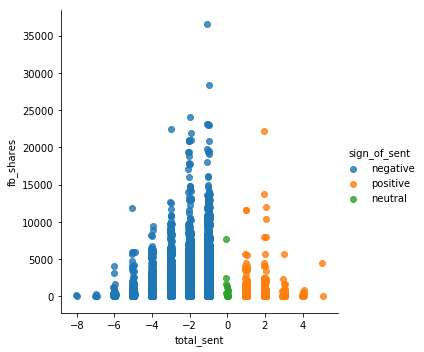

```python
#total_sent vs fb_shares
sns.lmplot(x= 'total_sent', y= 'fb_shares', data=df_art, hue= 'sign_of_sent', x_jitter= .07, fit_reg=False)
```

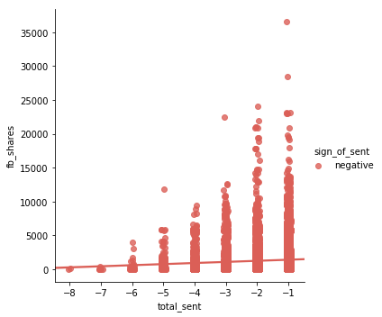

```python
#we can also do seperate regressions for each type of sentiment
sns.lmplot(x= 'total_sent', y= 'fb_shares', data=df_art[df_art['sign_of_sent']== "negative"], hue= 'sign_of_sent', x_jitter= .07, palette= sns.color_palette("hls", 3))
```

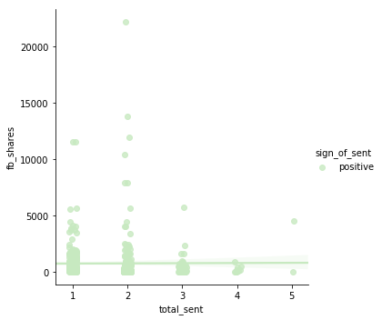

```python
#analyze fb shares that are positive
sns.lmplot(x= 'total_sent', y= 'fb_shares', data=df_art[df_art['sign_of_sent']== "positive"], hue= 'sign_of_sent', x_jitter= .07, palette= sns.color_palette("Greens", 3))
```

### Analysis

We can see that the range of facebook likes and shares for negative sentiment surpasses those of the positive sentiment:

Likes: Negative: 300,000+; Positive: 150,000 Shares: Negative: 35,000; Positive: a little less than 25,000

We can also see that there are far more articles with negative sentiments than positive sentiments. There are also more overall extremes for the negative sentiments themselves. The lowest sentiment is -8, and the highest sentiment is 5.

From this analyses, we can come up with a few conclusions:

```
1. Articles with negative sentiment tend to have more likes and shares than articles with positive sentiment
2. Articles that do have negative sentiments have a bigger range of being negative, specifically [-8, 0) compared to a smaller range for positive sentiments,  (0, 5]
3. There are more negative articles than positive articles out there
```

#### Disclaimer

These conclusions have a lot of potential of being skewed/false. The data used to come up with the analyses is only a small set from the data that was scraped. And that subset of data is not randomized. Results can vary depending on the sample size and randomness of the sample.

The difference in range and number of positive and negative articles may be also due to selecting the sample, and they conclusions may change with a more random sample. It would be interesting to rerun the analyses with different subsets of the sample. If the conclusions remain the same with different sampling methodologies, then there’s a higher chance that the given conclusions above are true.

#### A Small Extension

```python
df_sent[df_sent['tag']=="trump"].head()
```

|  | domain_rank | fb_comments | fb_likes | fb_shares | performance_score | sentiment | site | spam_score | tag | title | uuid | sent_metric |
| --- | --- | --- | --- | --- | --- | --- | --- | --- | --- | --- | --- | --- |
| 5 | 139.0 | 147614 | 249425 | 36600 | 10 | negative | huffingtonpost.com | 0.0 | trump | Every President Recited This Prayer Except Tru... | d13abf959e176105e8be4a8715f4e74434eb2cfc | -1 |
| 25 | 81.0 | 94401 | 197419 | 19380 | 10 | negative | cnn.com | 0.0 | trump | Trump: I'm thankful for the difference I've ma... | 6bf05f1935bf304834b694db85704e09b448c537 | -1 |
| 27 | 81.0 | 94073 | 197419 | 19380 | 10 | negative | cnn.com | 0.0 | trump | Trump: I'm thankful for the difference I've ma... | 6258e202b52da859edf569623b7a99b3ad0e7fc3 | -1 |
| 160 | 185.0 | 12407 | 122155 | 6003 | 10 | negative | foxnews.com | 0.0 | trump | Bush family wants funeral that avoids anti-Tru... | eb6dc2fd56f25d27733bd61fc3bdc528e15014ca | -1 |
| 169 | 185.0 | 12208 | 121583 | 5810 | 10 | negative | foxnews.com | 0.0 | trump | Bush family wants funeral that avoids anti-Tru... | 8b0b94c005a9612914a7904d8191fd813f4f7400 | -1 |

The articles that were sampled may also have an incredible amount of negative tags for reasons not so random. As seen here, there are multiple tags, “trump”, that had a negative sentiment attached to them. Donald J Trump is a very controversial figure. Trends in journalism have a great effect to what articles are put out there, and what is available to readers. The conspiracy of the 45th presidency has garnered a lot of attention just only over the past few years, and this data does not accurately reflect media over time.

## Conclusion

The tagged people, tagged locations, and tagged media locations had a somewhat significant impact on the popularity of the article. The sentiment also associated with those tags have an effect on the amount of shares and likes. We can conclude that if journalists want to create a really popular article, they should write about divisive topics such as Donald Trump and Brexit. The most popular articles will also be from popular media organizations, and written about in a negative light.

## Appendix

Code used to gather datca:

```
!pip install webhoseio
import pandas as pd
import webhoseio

# put your own webhoseio api key in the my_api_key variable.
# (run api_key.py is to prevent the key from being shown publicly on github)
# There will be a error, but it won't affect anything.

my_api_key = ""
%run api_key.py

# Try to avoid re-running this one alot we have 1000 queries max.

webhoseio.config(token=my_api_key)
query_params = {
    "q": "language:english site_type:news social.facebook.likes:>500",
    "ts": "1542059049078",
    "sort": "social.facebook.likes"
    }

output = webhoseio.query("filterWebContent", query_params)


i = 0
t = 838
data_persons = []
data_organizations = []
data_locations = []
data_notags = []
for x_r in range(t):

    for post in output['posts']:
        d_base = {
                'title' : post['thread']['title'],
                'fb_likes' : post['thread']['social']['facebook']['likes'],
                'fb_comments' : post['thread']['social']['facebook']['comments'],
                'fb_shares' : post['thread']['social']['facebook']['shares'],
                'spam_score' : post['thread']['spam_score'],
                'performance_score' : post['thread']["performance_score"],
                'domain_rank' : post['thread']['domain_rank'],
                'site' : post['thread']['site'],
                'uuid' : post['thread']['uuid']
            }
        data_notags.append(d_base)
        for person in post['entities']['persons']:
            d_p = d_base.copy()
            d_p['tag'] = person['name']
            d_p['sentiment'] = person['sentiment']
            data_persons.append(d_p)
        for organization in post['entities']['organizations']:
            d_o = d_base.copy()
            d_o['tag'] = organization['name']
            d_o['sentiment'] = organization['sentiment']
            data_organizations.append(d_o)
        for location in post['entities']['locations']:
            d_l = d_base.copy()
            d_l['tag'] = location['name']
            d_l['sentiment'] = organization['sentiment']
            data_locations.append(d_l)
    i = i+1
    print(str(i*100) + ' / 83850')
    output = webhoseio.get_next()


df_persons = pd.DataFrame(data_persons)
df_organizations = pd.DataFrame(data_organizations)
df_locations = pd.DataFrame(data_locations)
df_all = pd.DataFrame(data_persons+data_organizations+data_locations)
df_notags = pd.DataFrame(data_notags)
display(df_all)
```

Then we saved the data to CSVs for later use. We import these CSVs into dataframes.

```
df_dict = {"df_persons":df_persons,
           "df_organizations":df_organizations,
           "df_locations":df_locations,
           "df_all":df_all,
           "df_notags":df_notags}
for k, v in df_dict.items():
    v.to_csv(k+".csv")
```